install.packages(“logistf”)

```r
library(logistf)
library(tidyverse)
```

r”( … )”

```r
data <- read.csv(r"(C:\Users\hidy0\Desktop\consultation\meat\meat (1).csv)")
data
```

```
##    Time   pH
## 1     1 7.02
## 2     1 6.93
## 3     2 6.42
## 4     2 6.51
## 5     4 6.07
## 6     4 5.99
## 7     6 5.59
## 8     6 5.80
## 9     8 5.51
## 10    8 5.36
## 11   24 5.30
## 12   24 5.47
```

```r
linear_m <- lm(pH ~ Time, data)
quad_m <- lm(pH ~ Time + I(Time^2), data)

anova(linear_m, quad_m)
```

```
## Analysis of Variance Table
##
## Model 1: pH ~ Time
## Model 2: pH ~ Time + I(Time^2)
##   Res.Df     RSS Df Sum of Sq      F    Pr(>F)
## 1     10 1.97289
## 2      9 0.13782  1    1.8351 119.84 1.677e-06 ***
## ---
## Signif. codes:  0 '***' 0.001 '**' 0.01 '*' 0.05 '.' 0.1 ' ' 1
```

```r
data <- read.csv(r"(C:\Users\hidy0\Desktop\consultation\meat\meat (1).csv)")

# Recode pH into a binary outcome
data$y <- ifelse(data$pH <= 6, 1, 0)

library(logistf)

firth_m <- logistf(y ~ Time, data = data)
summary(firth_m)
```

```
## logistf(formula = y ~ Time, data = data)
##
## Model fitted by Penalized ML
## Coefficients:
##                   coef  se(coef) lower 0.95 upper 0.95    Chisq           p
## (Intercept) -3.7185131 2.0583677 -6.4018533 -0.2981945 4.529084 0.033323459
## Time         0.9158853 0.4756127  0.1075869  1.9718842 7.184868 0.007352096
##             method
## (Intercept)      2
## Time             2
##
## Method: 1-Wald, 2-Profile penalized log-likelihood, 3-None
##
## Likelihood ratio test=7.184868 on 1 df, p=0.007352096, n=12
## Wald test = 3.724683 on 1 df, p = 0.05361379
```

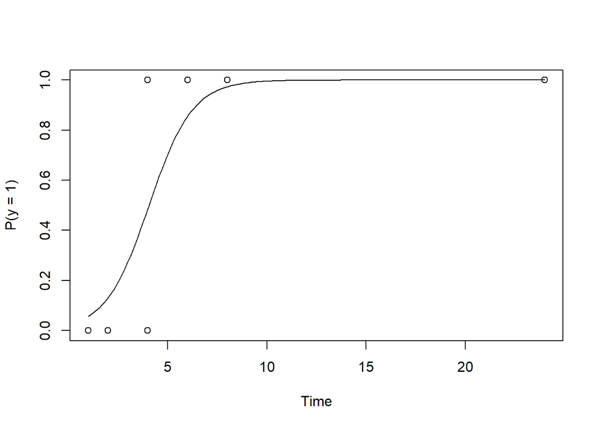

```r
plot(data$Time, data$y,
     xlab = "Time",
     ylab = "P(y = 1)",
     ylim = c(0, 1))

tt <- seq(min(data$Time), max(data$Time), length.out = 200)

lines(
  tt,
  predict(
    firth_m,
    newdata = data.frame(Time = tt),
    type = "response"
  )
)
```

#Asymptotic regression

```r
data <- read.csv(r"(C:\Users\hidy0\Desktop\consultation\meat\meat (1).csv)")

asym_m <- nls(
  pH ~ a + b * exp(-c * Time),
  data = data,
  start = list(
    a = 5,
    b = 2,
    c = 0.3
  )
)

summary(asym_m)
```

```
##
## Formula: pH ~ a + b * exp(-c * Time)
##
## Parameters:
##   Estimate Std. Error t value Pr(>|t|)
## a  5.35303    0.06515  82.169 2.97e-14 ***
## b  2.21838    0.13146  16.875 4.04e-08 ***
## c  0.32292    0.04190   7.707 2.98e-05 ***
## ---
## Signif. codes:  0 '***' 0.001 '**' 0.01 '*' 0.05 '.' 0.1 ' ' 1
##
## Residual standard error: 0.1008 on 9 degrees of freedom
##
## Number of iterations to convergence: 4
## Achieved convergence tolerance: 7.979e-06
```

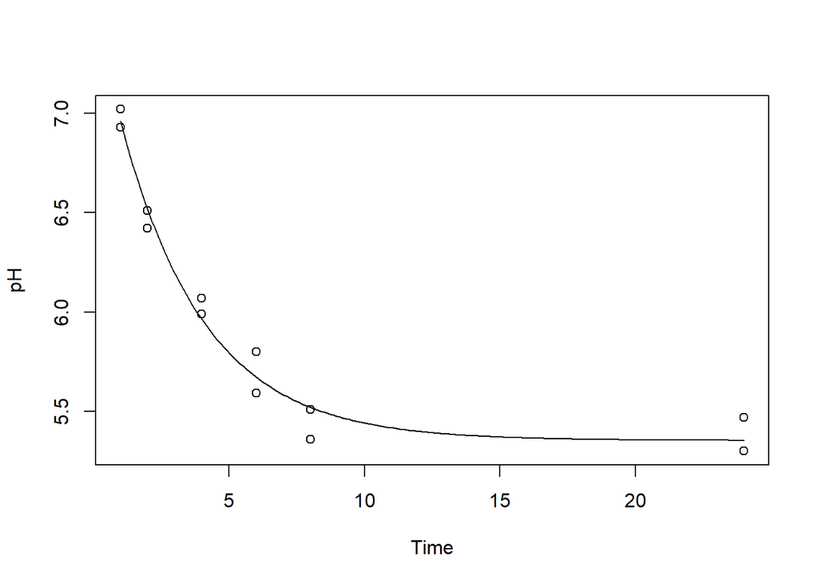

```r
plot(data$Time, data$pH,
     xlab = "Time",
     ylab = "pH")

tt <- seq(min(data$Time), max(data$Time), length.out = 200)

lines(
  tt,
  predict(
    asym_m,
    newdata = data.frame(Time = tt)
  )
)
```

#EDA (Exploaratory data analysis)

```r
str(data)
```

```
## 'data.frame':    12 obs. of  2 variables:
##  $ Time: int  1 1 2 2 4 4 6 6 8 8 ...
##  $ pH  : num  7.02 6.93 6.42 6.51 6.07 5.99 5.59 5.8 5.51 5.36 ...
```

```r
summary(data)
```

```
##       Time            pH
##  Min.   : 1.0   Min.   :5.300
##  1st Qu.: 2.0   1st Qu.:5.500
##  Median : 5.0   Median :5.895
##  Mean   : 7.5   Mean   :5.997
##  3rd Qu.: 8.0   3rd Qu.:6.442
##  Max.   :24.0   Max.   :7.020
```

Time is integer and pH is numeric

Q. Were the two pH values at each time point measured repeatedly from the same two samples over time, or were two different samples measured at each time point?

##case 1 Suppose the same samples are measured repeatedly over time.

For example, the first sample measured at Time 1 is the same sample measured at Time 2, Time 4, and so on.

Because repeated measurements come from the same sample, the observations may be correlated rather than fully independent.

For example, a sample with a relatively high pH at one time point may also tend to have a relatively high pH at later time points.

Therefore, a simple linear model that assumes independent observations may not be appropriate. Depending on the situation, we may need a repeated-measures model, a mixed-effects model, or a model that explicitly accounts for the correlation structure.

Since there are two samples at each time point, I think we should label the sample values as 1 and 2, because it doesn’t identify which observation belongs to Sample1 versus Sample2.

```r
data$Sample <- rep(c("Sample1", "Sample2"), 6)

data
```

```
##    Time   pH  Sample
## 1     1 7.02 Sample1
## 2     1 6.93 Sample2
## 3     2 6.42 Sample1
## 4     2 6.51 Sample2
## 5     4 6.07 Sample1
## 6     4 5.99 Sample2
## 7     6 5.59 Sample1
## 8     6 5.80 Sample2
## 9     8 5.51 Sample1
## 10    8 5.36 Sample2
## 11   24 5.30 Sample1
## 12   24 5.47 Sample2
```

And then it’s useful to plot how PH changes over time

```r
plot(data$Time, data$pH)
```

[output not shown]

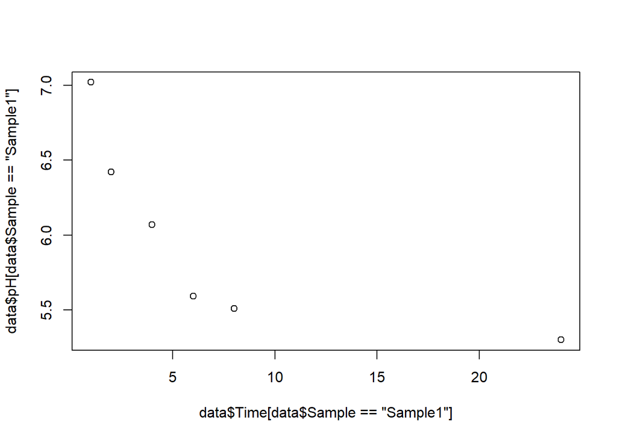

```r
plot(data$Time[data$Sample == "Sample1"], data$pH[data$Sample == "Sample1"])
```

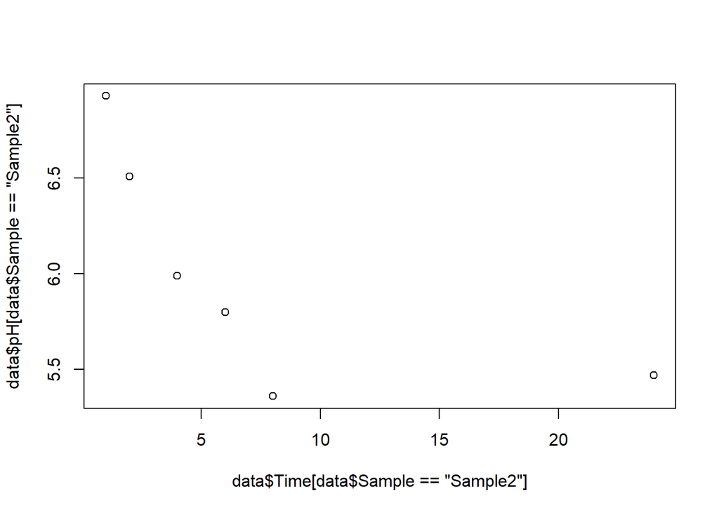

```r
plot(data$Time[data$Sample == "Sample2"], data$pH[data$Sample == "Sample2"])
```

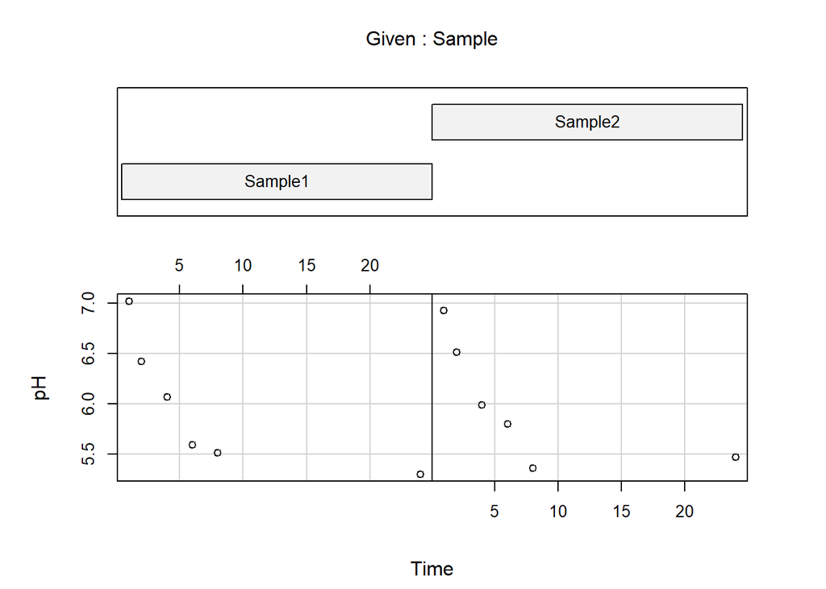

```r
coplot(pH ~ Time | Sample, data)
```

Both shows similar downward pattern = They behave similarly.

Check the shape trend of relationship bet pH and Time -abline() adds a straight line to an existing plot. Here, it adds the regression line produced by lm() on top of the scatterplot.

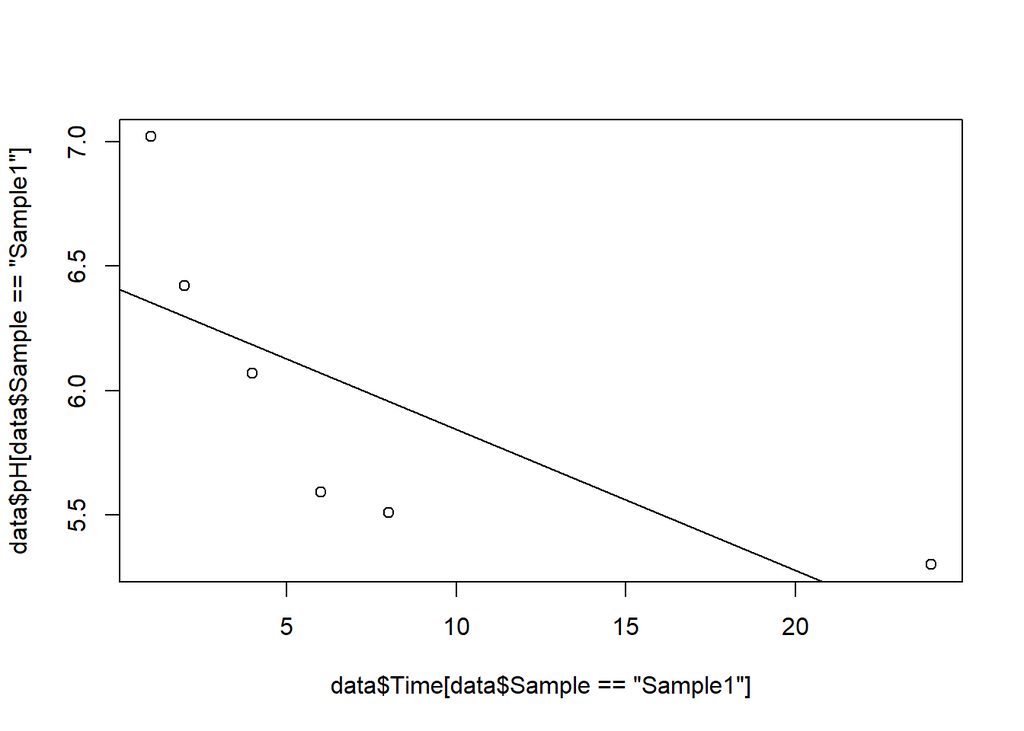

```r
plot(data$Time[data$Sample == "Sample1"],
     data$pH[data$Sample == "Sample1"])
abline(lm(pH ~ Time, data[data$Sample == "Sample1", ]))
```

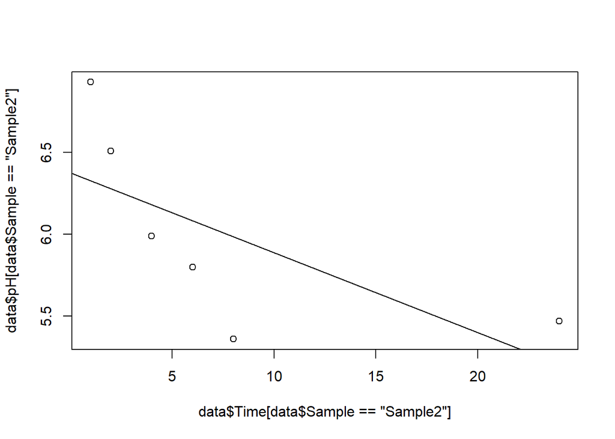

```r
plot(data$Time[data$Sample == "Sample2"],
     data$pH[data$Sample == "Sample2"])
abline(lm(pH ~ Time, data[data$Sample == "Sample2", ]))
```

```r
data1 <- subset(data, Sample = "Sample1")
```

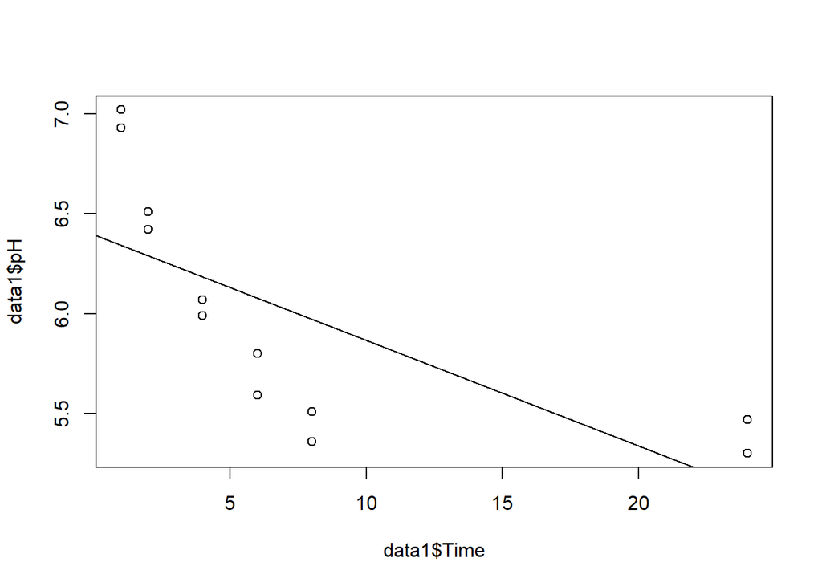

```r
plot(data1$Time, data1$pH)
abline(lm(pH ~ Time, data1))
```

visual evidence: linear not fit well /

```r
linear_m <- lm(pH ~ Time, data)
quad_m <- lm(pH ~ Time + I(Time^2), data)

anova(linear_m, quad_m)
```

```
## Analysis of Variance Table
##
## Model 1: pH ~ Time
## Model 2: pH ~ Time + I(Time^2)
##   Res.Df     RSS Df Sum of Sq      F    Pr(>F)
## 1     10 1.97289
## 2      9 0.13782  1    1.8351 119.84 1.677e-06 ***
## ---
## Signif. codes:  0 '***' 0.001 '**' 0.01 '*' 0.05 '.' 0.1 ' ' 1
```

If the p-value is smaller than the significance level $\alpha$, we reject $H_0$ = we reject the hypothesis that the quadratic term is unnecessary.

=The very small p-value indicates that adding the quadratic term substantially improves the fit compared with the simple linear model.

The key point is that the slope $\beta_1$ is constant everywhere.
$$\text{pH} = \beta_0 + \beta_1 \text{Time}$$

Once this term is included, the slope no longer has to stay constant. In other words, the rate of decline is allowed to change over time.
$$\text{pH}
=
\beta_0
+
\beta_1 \text{Time}
+
\beta_2 \text{Time}^2$$

So the curvature test is essentially asking: Do we need $\beta_2$?

ANOVA(Analysis of Variance) “After adding the quadratic term, did the unexplained variation decrease enough?”

NA

```r
sum(is.na(data))
```

```
## [1] 0
```

outlier

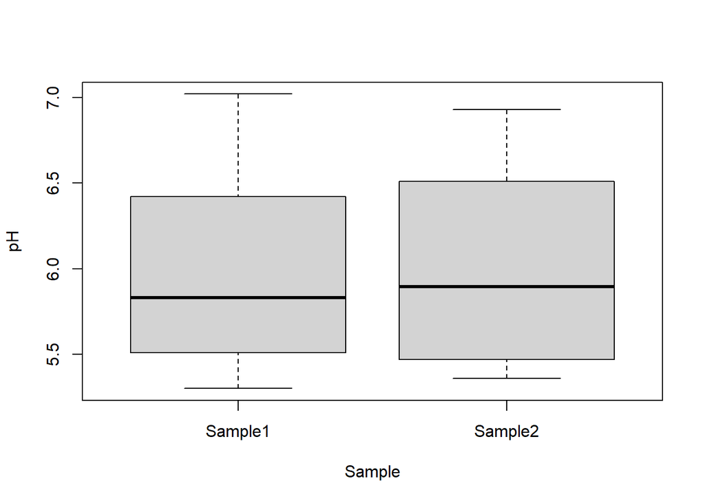

```r
boxplot(pH ~ Sample, data)
```

```r
plot(data$Time, data$pH)
```

[output not shown]

EDA result -Time was imported as an integer and pH as a numeric variable. -Both samples showed a similar decreasing pattern in pH over time. -Adding a quadratic term substantially improved the model fit, suggesting strong evidence of curvature. -No obvious outliers or unusually inconsistent observations were apparent from the boxplot or the pH–Time plot.

#model selection and justification 1. same samples were repeatedly measured 2. The pH–Time relationship appears curved / nonlinear rather than simply linear.

-> “What model can account for both of these features?”

“mixed-effects model with a quadratic time effect”

$$\text{pH}_{ij}
=
\beta_0
+
\beta_1\text{Time}_{ij}
+
\beta_2\text{Time}_{ij}^2
+
b_i
+
\epsilon_{ij}$$
A mixed-effects model combines the overall common pattern with sample-specific differences.

It is called mixed because it combines fixed effects and random effects.

- Fixed effect = Time → This is the overall effect we are interested in.
- Random effect = Sample → This represents natural differences among samples.

fit the model using lmer

```r
library(lme4)
model <- lmer(pH ~ Time + I(Time^2) + (1|Sample), data)
```

```
## boundary (singular) fit: see help('isSingular')
```

```r
summary(model)
```

```
## Linear mixed model fit by REML ['lmerMod']
## Formula: pH ~ Time + I(Time^2) + (1 | Sample)
##    Data: data
##
## REML criterion at convergence: 7
##
## Scaled residuals:
##     Min      1Q  Median      3Q     Max
## -1.2836 -0.7626 -0.1722  0.7199  1.4164
##
## Random effects:
##  Groups   Name        Variance Std.Dev.
##  Sample   (Intercept) 0.00000  0.0000
##  Residual             0.01531  0.1237
## Number of obs: 12, groups:  Sample, 2
##
## Fixed effects:
##               Estimate Std. Error t value
## (Intercept)  7.1290406  0.0836126   85.26
## Time        -0.2935194  0.0224709  -13.06
## I(Time^2)    0.0092097  0.0008413   10.95
##
## Correlation of Fixed Effects:
##           (Intr) Time
## Time      -0.872
## I(Time^2)  0.804 -0.979
## optimizer (nloptwrap) convergence code: 0 (OK)
## boundary (singular) fit: see help('isSingular')
```

```r
fixef(model)
```

```
##  (Intercept)         Time    I(Time^2)
##  7.129040560 -0.293519360  0.009209653
```

```r
ranef(model)
```

```
## $Sample
##         (Intercept)
## Sample1           0
## Sample2           0
##
## with conditional variances for "Sample"
```

```r
VarCorr(model)
```

```
##  Groups   Name        Std.Dev.
##  Sample   (Intercept) 0.00000
##  Residual             0.12375
```

```r
fitted(model)
```

```
##        1        2        3        4        5        6        7        8
## 6.844731 6.844731 6.578840 6.578840 6.102318 6.102318 5.699472 5.699472
##        9       10       11       12
## 5.370303 5.370303 5.389336 5.389336
```

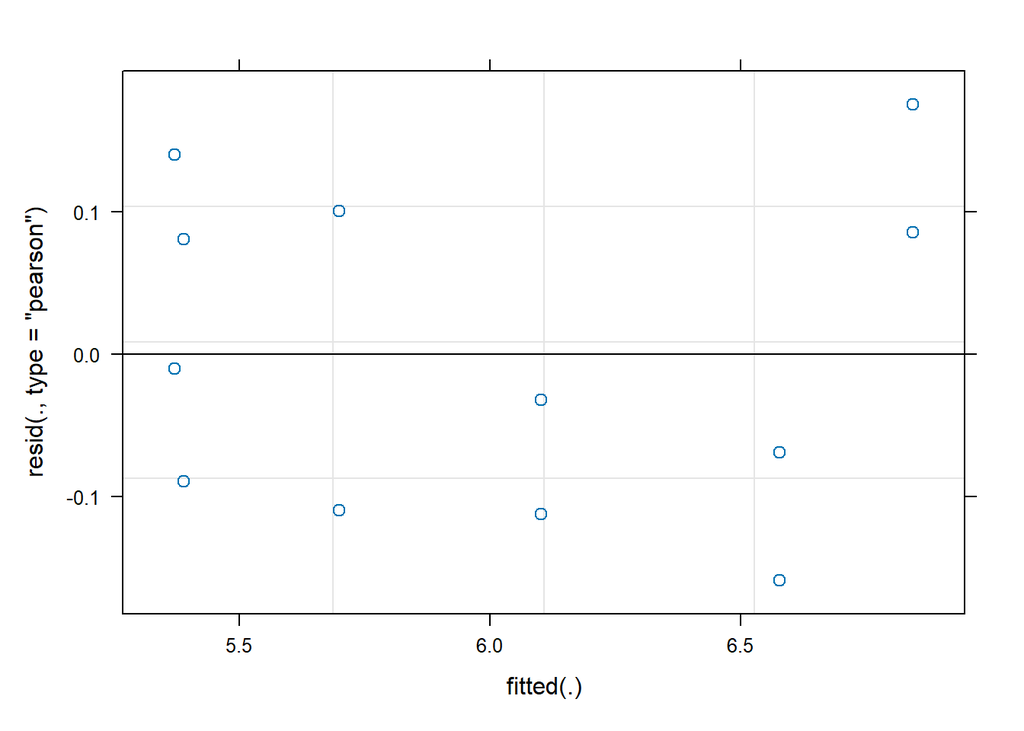

```r
plot(model)
```

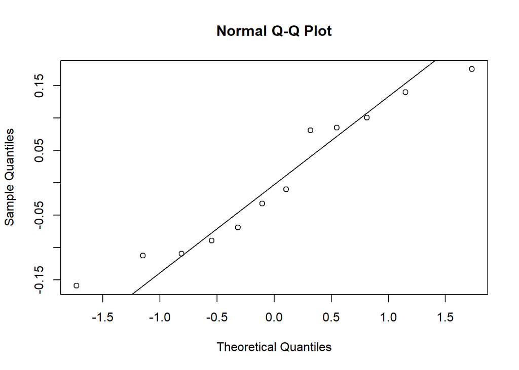

```r
qqnorm(resid(model))
qqline(resid(model))
```

#Case2: Independent

r”( … )”

```r
data <- read.csv(r"(C:\Users\hidy0\Desktop\consultation\meat\meat (1).csv)")
data
```

```
##    Time   pH
## 1     1 7.02
## 2     1 6.93
## 3     2 6.42
## 4     2 6.51
## 5     4 6.07
## 6     4 5.99
## 7     6 5.59
## 8     6 5.80
## 9     8 5.51
## 10    8 5.36
## 11   24 5.30
## 12   24 5.47
```

The observations should not be linked across time because they come from different samples. Each row represents one independent observation.

```r
str(data)
```

```
## 'data.frame':    12 obs. of  2 variables:
##  $ Time: int  1 1 2 2 4 4 6 6 8 8 ...
##  $ pH  : num  7.02 6.93 6.42 6.51 6.07 5.99 5.59 5.8 5.51 5.36 ...
```

```r
summary(data)
```

```
##       Time            pH
##  Min.   : 1.0   Min.   :5.300
##  1st Qu.: 2.0   1st Qu.:5.500
##  Median : 5.0   Median :5.895
##  Mean   : 7.5   Mean   :5.997
##  3rd Qu.: 8.0   3rd Qu.:6.442
##  Max.   :24.0   Max.   :7.020
```

```r
plot(data$Time, data$pH)
```

[output not shown]

The scatterplot suggests that pH decreases over time. The relationship may not be perfectly linear. There are no obvious outliers.

*Analysis of Variance :it is partitioning variation and comparing how much variation is explained versus unexplained.

```r
linear_m <- lm(pH ~ Time, data)
quad_m <- lm(pH ~ Time + I(Time^2), data)
anova(linear_m, quad_m)
```

```
## Analysis of Variance Table
##
## Model 1: pH ~ Time
## Model 2: pH ~ Time + I(Time^2)
##   Res.Df     RSS Df Sum of Sq      F    Pr(>F)
## 1     10 1.97289
## 2      9 0.13782  1    1.8351 119.84 1.677e-06 ***
## ---
## Signif. codes:  0 '***' 0.001 '**' 0.01 '*' 0.05 '.' 0.1 ' ' 1
```

We compared a simple linear regression model with a quadratic regression model.

RSS measures the amount of unexplained variation remaining after fitting the model. -> Quadratic RSS = 0.14: The quadratic model leaves much less unexplained variation than the linear model.

But adding another predictor almost always reduces RSS. -> The F-test(Fisher’s F statistic) is used to determine whether the null hypothesis should be rejected.

$$F
=
\frac{\text{Extra variation explained by }Time^2}
{\text{Residual variation}}$$

small pvalue: reject the null hypothesis and conclude that the quadratic term should be included in the model.

$$H_0:\beta_2=0$$

```r
summary(quad_m)
```

```
##
## Call:
## lm(formula = pH ~ Time + I(Time^2), data = data)
##
## Residuals:
##      Min       1Q   Median       3Q      Max
## -0.15884 -0.09437 -0.02131  0.08908  0.17527
##
## Coefficients:
##               Estimate Std. Error t value Pr(>|t|)
## (Intercept)  7.1290406  0.0836126   85.26 2.13e-14 ***
## Time        -0.2935194  0.0224709  -13.06 3.73e-07 ***
## I(Time^2)    0.0092097  0.0008413   10.95 1.68e-06 ***
## ---
## Signif. codes:  0 '***' 0.001 '**' 0.01 '*' 0.05 '.' 0.1 ' ' 1
##
## Residual standard error: 0.1237 on 9 degrees of freedom
## Multiple R-squared:  0.9653, Adjusted R-squared:  0.9576
## F-statistic: 125.3 on 2 and 9 DF,  p-value: 2.689e-07
```

$$\widehat{\text{pH}}
=
7.129
-
0.294(\text{Time})
+
0.0092(\text{Time}^2)$$

I understand that the linear term is negative and the quadratic term is positive, but I’m having trouble understanding what that actually means in practice. SO what does that mean for how pH changes over time?

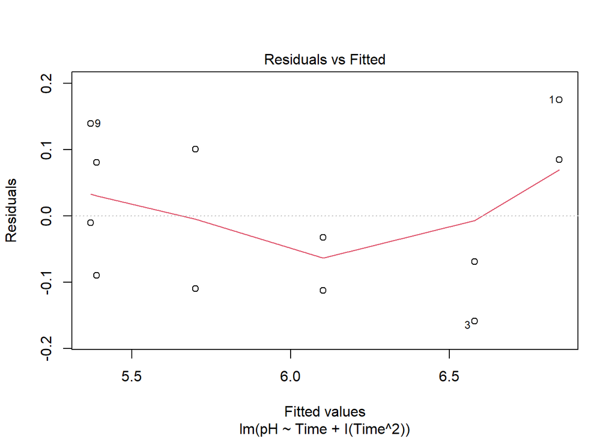

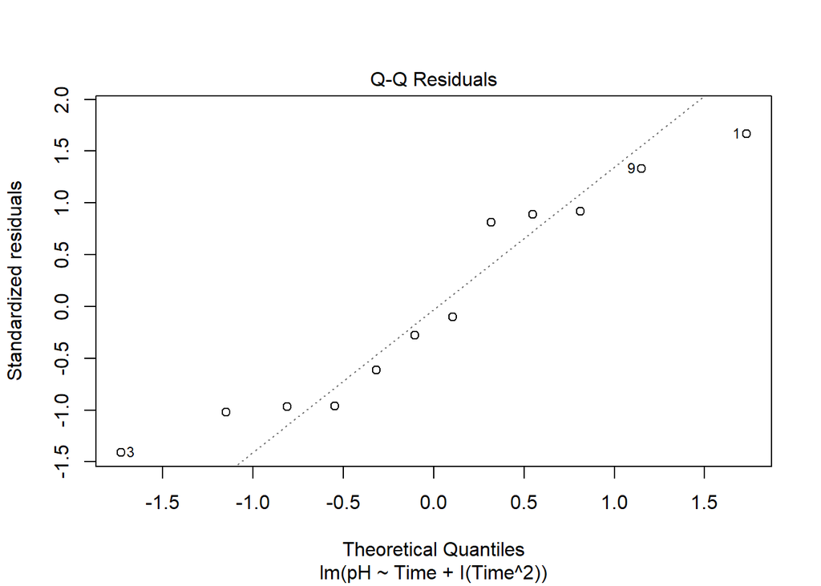

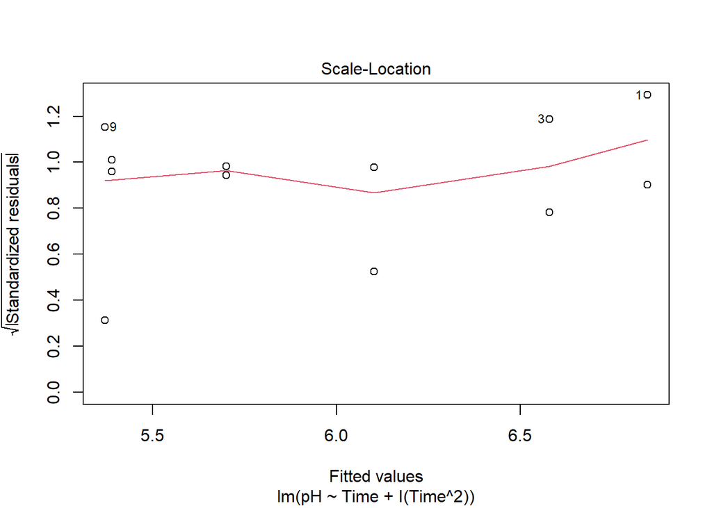

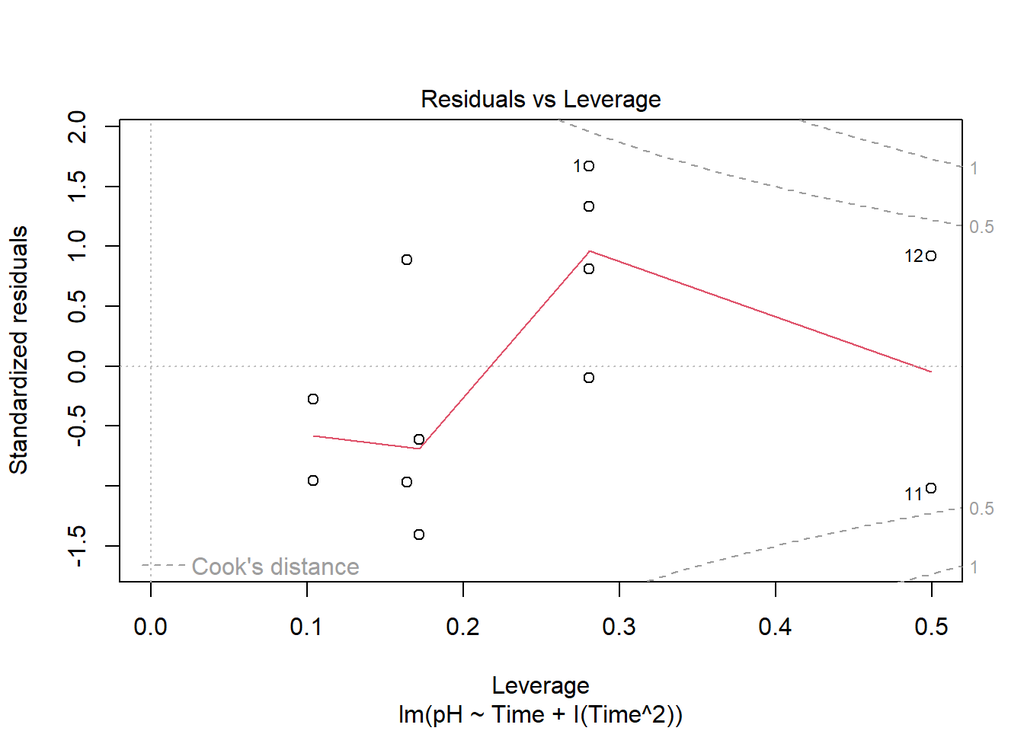

```r
plot(quad_m)
```

If the points closely follow the reference line, it suggests that the residuals are approximately normally distributed and mostly centered around zero.

- qqnorm() plots the observed residuals as points.
- qqline() draws the reference line representing the pattern expected if the residuals were normally distributed.

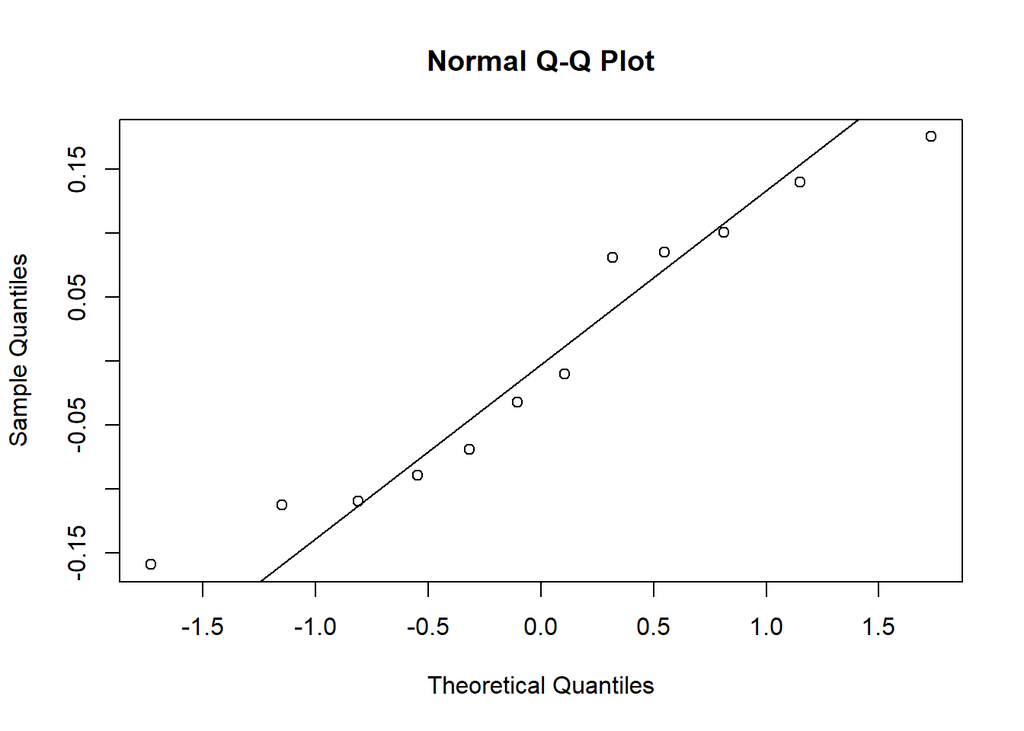

```r
qqnorm(resid(quad_m))
#reference line
qqline(resid(quad_m))
```